# Practical Machine Learning Course Project

Ersi Ni

January 24, 2015

This is the project report of the Practical Machine Learning Course Project on Coursera Course predmachlearn-010.

### Introduction

#### Background

Using devices such as Jawbone Up, Nike FuelBand, and Fitbit it is now possible to collect a large amount of data about personal activity relatively inexpensively. These type of devices are part of the quantified self movement  a group of enthusiasts who take measurements about themselves regularly to improve their health, to find patterns in their behavior, or because they are tech geeks. One thing that people regularly do is quantify how much of a particular activity they do, but they rarely quantify how well they do it. In this project, your goal will be to use data from accelerometers on the belt, forearm, arm, and dumbell of 6 participants. They were asked to perform barbell lifts correctly and incorrectly in 5 different ways. More information is available from the website here: http://groupware.les.inf.puc-rio.br/har (see the section on the Weight Lifting Exercise Dataset)."

#### Data

The data for this project come from this source: http://groupware.les.inf.puc-rio.br/har. The information has been generously provided for use use in this cousera course by the authors, Velloso, E.; Bulling, A.; Gellersen, H.; Ugulino, W.; Fuks, H. They have allowed the use of their paper “Qualitative Activity Recognition of Weight Lifting Exercises. Proceedings of 4th International Conference in Cooperation with SIGCHI (Augmented Human ’13) . Stuttgart, Germany: ACM SIGCHI, 2013.

The training data for this project are available here:

https://d396qusza40orc.cloudfront.net/predmachlearn/pml-training.csv

The test data are available here:

https://d396qusza40orc.cloudfront.net/predmachlearn/pml-testing.csv

#### Abstract

In this report the solution being developed is explained in 4 Sections: Getting and Cleaning Data, Data Splitting and Cross Validation, Trial for Machine Learning Algorithms and finally the Final Model and its reasonings

In this report the code is made reproducible that you can grab the R-Markdown file from the Github Repo and produce the same report you are reading right now. Libraries for R being used are `caret`, `randomForest`, `doMC` or `doParallel`. Further, I chose seed `124`.

```r
library(caret)
library(randomForest)
library(doParallel)
cl<-makeCluster(4)
registerDoParallel(cl)
# library(doMC)
# registerDoMC(cores = 4)
library(e1071)
set.seed(124)
```

### Getting and Cleaning Data

Getting data by downloading the two csv files and assign NA value to NA fields. Missing values are represented in these strings inside the data set: `"#DIV/0!" "NA" ""`

```r
naStrings<-c("NA","#DIV/0!","")
if(!file.exists("pml-training.csv")){download.file(url = "https://d396qusza40orc.cloudfront.net/predmachlearn/pml-training.csv", destfile = "pml-training.csv", method = "curl")}
if(!file.exists("pml-testing.csv")){download.file(url = "https://d396qusza40orc.cloudfront.net/predmachlearn/pml-testing.csv", destfile = "pml-testing.csv", method = "curl")}
training <- read.csv("pml-training.csv", na.strings=naStrings, header = T)
testing <- read.csv("pml-testing.csv", na.strings=naStrings, header = T)
```

Here I present my understanding of the Raw data characteristics and how I clean them to fit my needs.

When inspecting the raw data with commands such as `summary(rawData)` or `nearZeroVar(rawData)` I realized that there are many columns composed with mostly `NA` values. Therefore the first step is to remove the `NA` values from the data.

I first define a function to let me see which column has how many non `NA` values.

```r
HasValueCounts <- function(x) as.vector(apply(x,2,function(x) length(which(!is.na(x)))))
```

Upon inspecting the summary of the result from the function I realized there are 2 major classes of variable which has non NA values:

```r
summary(HasValueCounts(training))
```

```
##    Min. 1st Qu.  Median    Mean 3rd Qu.    Max.
##       0     406     406    7590   19620   19620
```

The difference between 3rd Quantile and 1st Quantile is so large that it is unlikely the observations on `406` group will be a significant predictor of the outcome. Therefore I left them out.

```r
colnames_goodColumns <- function(x) {
  cnts<-HasValueCounts(x)
  drops<-c()
  for(index in 1:length(cnts)){
    if(cnts[index] < nrow(x)){
      drops<-c(drops,index)
    }
  }
  -drops
}

nzvIndex <- function(x){
  nzvMatrix <- nearZeroVar(x, saveMetrics = T)
  nzvMatrix$nzv==F
}
```

```r
cleanDataSet <- function(x) {
  tr <- x[,6:dim(x)[2]]
  keep <- colnames_goodColumns(tr)
  tr <- tr[,keep]
  nnzv <- nzvIndex(tr)
  tr <- tr[,nnzv]
  tr
}

training <- cleanDataSet(training)

# testing set
testing <- cleanDataSet(testing)
```

### Data splitting and cross validation

I sampled 60% of the training set to be my training set, on the rest 40% I built the cross-validation set. I then designate 1/4 of the cross validation set to be test set of the cross validation.

```r
inTrain <- createDataPartition(training$classe, p = 0.6)[[1]]
cv <- training[-inTrain,]
training <- training[ inTrain,]
inTrain <- createDataPartition(cv$classe, p = 0.75)[[1]]
cv_test <- cv[ -inTrain,]
cv <- cv[inTrain,]
```

### Trial Machine Learning Algorithms

On the exploratory analysis I chose **random forest** and **linear discriminant analysis** to attack the data set. Because the exploratory data analysis reveals that the problem is non-linear.

```r
trial_rf <- train(classe ~ ., data=training, method="rf")
trial_lda <- train(classe ~ ., data=training, method="lda")
```

Running predictions on cross validation set

```r
pred_rf <- predict(trial_rf, cv)
pred_lda <- predict(trial_lda, cv)
```

Showing confusion matrix on cross validation set

```r
confusionMatrix(pred_rf, cv$classe)
```

```
## Confusion Matrix and Statistics
##
##           Reference
## Prediction    A    B    C    D    E
##          A 1674    5    0    0    0
##          B    0 1133    3    2    2
##          C    0    1 1020    5    0
##          D    0    0    3  957    2
##          E    0    0    0    1 1078
##
## Overall Statistics
##
##                Accuracy : 0.9959
##                  95% CI : (0.9939, 0.9974)
##     No Information Rate : 0.2844
##     P-Value [Acc > NIR] : < 2.2e-16
##
##                   Kappa : 0.9948
##  Mcnemar's Test P-Value : NA
##
## Statistics by Class:
##
##                      Class: A Class: B Class: C Class: D Class: E
## Sensitivity            1.0000   0.9947   0.9942   0.9917   0.9963
## Specificity            0.9988   0.9985   0.9988   0.9990   0.9998
## Pos Pred Value         0.9970   0.9939   0.9942   0.9948   0.9991
## Neg Pred Value         1.0000   0.9987   0.9988   0.9984   0.9992
## Prevalence             0.2844   0.1935   0.1743   0.1639   0.1838
## Detection Rate         0.2844   0.1925   0.1733   0.1626   0.1831
## Detection Prevalence   0.2853   0.1937   0.1743   0.1634   0.1833
## Balanced Accuracy      0.9994   0.9966   0.9965   0.9953   0.9980
```

```r
confusionMatrix(pred_lda, cv$classe)
```

```
## Confusion Matrix and Statistics
##
##           Reference
## Prediction    A    B    C    D    E
##          A 1383  159  105   45   50
##          B   48  739  118   30  163
##          C  105  154  657  119   98
##          D  132   48  119  733   92
##          E    6   39   27   38  679
##
## Overall Statistics
##
##                Accuracy : 0.712
##                  95% CI : (0.7003, 0.7236)
##     No Information Rate : 0.2844
##     P-Value [Acc > NIR] : < 2.2e-16
##
##                   Kappa : 0.6356
##  Mcnemar's Test P-Value : < 2.2e-16
##
## Statistics by Class:
##
##                      Class: A Class: B Class: C Class: D Class: E
## Sensitivity            0.8262   0.6488   0.6404   0.7596   0.6275
## Specificity            0.9148   0.9244   0.9021   0.9205   0.9771
## Pos Pred Value         0.7939   0.6730   0.5799   0.6521   0.8606
## Neg Pred Value         0.9298   0.9165   0.9224   0.9513   0.9209
## Prevalence             0.2844   0.1935   0.1743   0.1639   0.1838
## Detection Rate         0.2350   0.1256   0.1116   0.1245   0.1154
## Detection Prevalence   0.2960   0.1865   0.1925   0.1910   0.1340
## Balanced Accuracy      0.8705   0.7866   0.7712   0.8401   0.8023
```

### Final Model and analysis

Based on the confusion matrix results, I can assert that the random Forest yields better accuracy than LDA. The accuracy of the *Random Forest* is near 99.6%.

To deliver the **Out of sample error**, I calculate the predication on the `cv_test` set to get that figure, because I did’t use cv_test to do my training.

```r
oose<-predict(trial_rf, cv_test)

1 - (sum(oose == cv_test$classe) / length(oose))
```

```
## [1] 0.002040816
```

Combined aboved statements, `random forest` delivers 99.6% accuracy and has an out of sample error of 0.20%.

### Submit with Autograder

```r
pml_write_files = function(x){
n = length(x)
for(i in 1:n){
filename = paste0("problem_id_",i,".txt")
write.table(x[i],file=filename,quote=FALSE,row.names=FALSE,col.names=FALSE)
}
}
x <- testing

answers <- predict(trial_rf, newdata=x)
answers
```

```
##  [1] B A B A A E D B A A B C B A E E A B B B
## Levels: A B C D E
```

```r
pml_write_files(answers)
```

### Appendix: Plots of the model fit

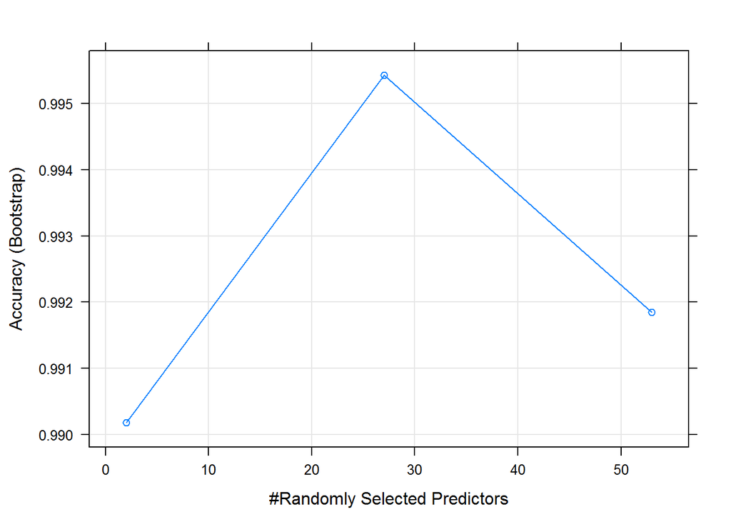

```r
plot(trial_rf)
```